# Principal Component Analysis - Python

### Background :

The "Sporting Goods Sales Data" shows sales of top 5 brands of the company in the first quarter of year 2023. The data also gives quarterly growth for these top 5 brands. The company has presence across the country and the data is available by Region-City.

### Objective :

Perform PCA on the provided sales data for the top 5 brands in the first quarter of year 2023, categorized by Region and City_Code. The goal is to reduce the dimensionality of the dataset while preserving the key information and identifying any underlying patterns or relationships among the variables

### Importing Libraries

```python
import pandas as pd
import numpy as np

import matplotlib.pyplot as plt
import seaborn as sns

from sklearn.decomposition import PCA
from sklearn.preprocessing import scale
```

### Importing Data

```python
data = pd.read_csv("Sporting Goods Sales Data.csv")
data.head()
```

|  | Region | City_Code | Sales_B1 | Growth_B1 | Sales_B2 | Growth_B2 | Sales_B3 | Growth_B3 | Sales_B4 | Growth_B4 | Sales_B5 | Growth_B5 |
| --- | --- | --- | --- | --- | --- | --- | --- | --- | --- | --- | --- | --- |
| 0 | EAST | 281 | 45.46 | 5.87 | 52.71 | 5.79 | 40.18 | 4.70 | 56.87 | 4.71 | 31.81 | 3.14 |
| 1 | EAST | 282 | 46.15 | 6.38 | 53.54 | 4.97 | 41.68 | 4.11 | 57.26 | 5.17 | 31.63 | 4.59 |
| 2 | EAST | 283 | 21.83 | 3.71 | 26.66 | 1.78 | 20.68 | 1.79 | 29.28 | 1.73 | 16.32 | 2.77 |
| 3 | EAST | 284 | 49.64 | 7.04 | 59.05 | 4.98 | 43.00 | 4.70 | 54.31 | 3.12 | 27.33 | 3.10 |
| 4 | EAST | 285 | 37.55 | 5.32 | 40.22 | 3.99 | 34.75 | 3.30 | 42.96 | 3.74 | 25.48 | 3.58 |

### Correlation Assessment

```python
data.corr()
```

|  | City_Code | Sales_B1 | Growth_B1 | Sales_B2 | Growth_B2 | Sales_B3 | Growth_B3 | Sales_B4 | Growth_B4 | Sales_B5 | Growth_B5 |
| --- | --- | --- | --- | --- | --- | --- | --- | --- | --- | --- | --- |
| City_Code | 1.000000 | -0.642714 | -0.620892 | -0.573386 | -0.630260 | -0.443622 | -0.502773 | -0.561271 | -0.579793 | -0.391254 | -0.514617 |
| Sales_B1 | -0.642714 | 1.000000 | 0.903556 | 0.976693 | 0.850452 | 0.767583 | 0.815407 | 0.825901 | 0.831460 | 0.693205 | 0.735340 |
| Growth_B1 | -0.620892 | 0.903556 | 1.000000 | 0.887854 | 0.908348 | 0.850162 | 0.881359 | 0.804373 | 0.864016 | 0.658215 | 0.850659 |
| Sales_B2 | -0.573386 | 0.976693 | 0.887854 | 1.000000 | 0.839793 | 0.755173 | 0.802752 | 0.757887 | 0.780232 | 0.646526 | 0.724352 |
| Growth_B2 | -0.630260 | 0.850452 | 0.908348 | 0.839793 | 1.000000 | 0.801383 | 0.839072 | 0.772158 | 0.820676 | 0.621128 | 0.827219 |
| Sales_B3 | -0.443622 | 0.767583 | 0.850162 | 0.755173 | 0.801383 | 1.000000 | 0.908143 | 0.859009 | 0.867161 | 0.831428 | 0.849335 |
| Growth_B3 | -0.502773 | 0.815407 | 0.881359 | 0.802752 | 0.839072 | 0.908143 | 1.000000 | 0.827739 | 0.896368 | 0.741791 | 0.842484 |
| Sales_B4 | -0.561271 | 0.825901 | 0.804373 | 0.757887 | 0.772158 | 0.859009 | 0.827739 | 1.000000 | 0.895053 | 0.920734 | 0.720545 |
| Growth_B4 | -0.579793 | 0.831460 | 0.864016 | 0.780232 | 0.820676 | 0.867161 | 0.896368 | 0.895053 | 1.000000 | 0.790791 | 0.804726 |
| Sales_B5 | -0.391254 | 0.693205 | 0.658215 | 0.646526 | 0.621128 | 0.831428 | 0.741791 | 0.920734 | 0.790791 | 1.000000 | 0.590880 |
| Growth_B5 | -0.514617 | 0.735340 | 0.850659 | 0.724352 | 0.827219 | 0.849335 | 0.842484 | 0.720545 | 0.804726 | 0.590880 | 1.000000 |

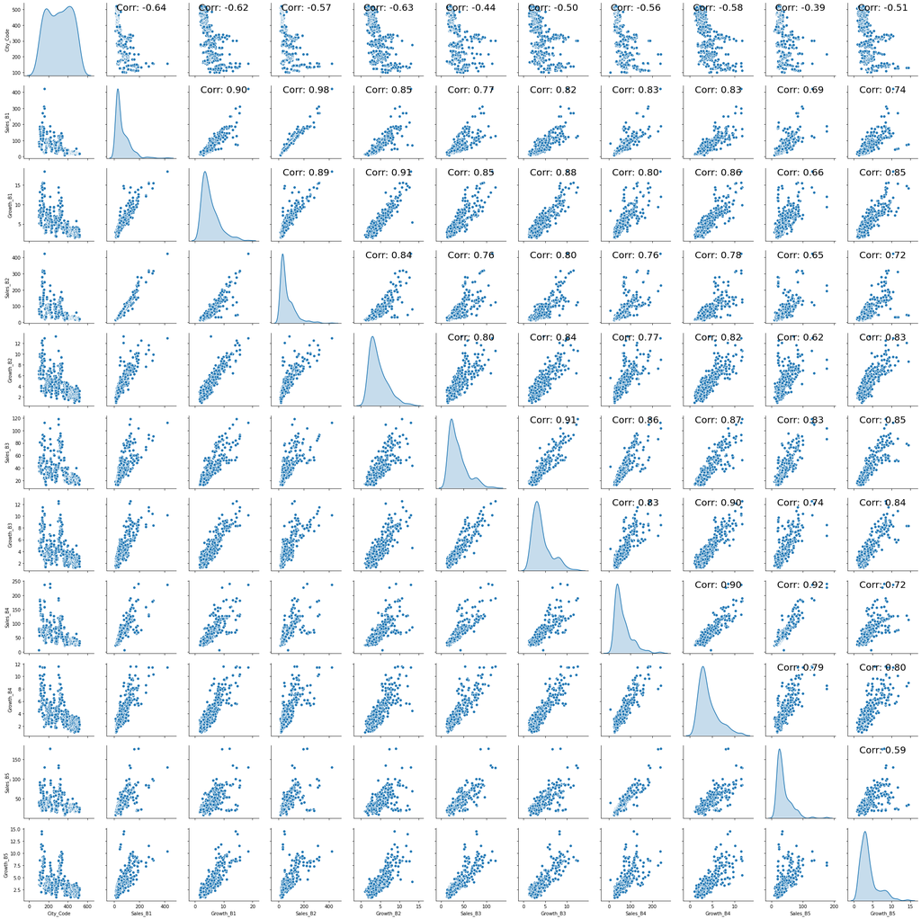

```python
df = data.copy()
# Calculate the correlation matrix
correlation_matrix = df.corr()

# Create a pair plot
g = sns.pairplot(df, diag_kind='kde', markers='o')

# Add coefficient numbers to the plots
for i, j in zip(*plt.np.triu_indices_from(g.axes, 1)):
    g.axes[i, j].annotate(f"Corr: {correlation_matrix.iloc[i, j]:.2f}", (0.5, 0.9), xycoords='axes fraction', ha='center', fontsize=20)

# Show the plot
plt.show()
```

### Dimensionality Reduction with PCA

```python
# Drop the 'Region' and 'City_Code' columns as they are not needed for PCA
sporting_data = data.drop(['Region', 'City_Code'], axis=1)
# Standardize the data by scaling it
standardisedX = scale(sporting_data)
# Create a DataFrame from the standardized data
X = pd.DataFrame(standardisedX, index=sporting_data.index, columns=sporting_data.columns)
# Initialize a PCA model and fit it to the standardized data
pca = PCA().fit(X)
# Generate names for the principal components (PC1, PC2, ..., PC10)
names = ["PC" + str(i) for i in range(1, 11)]
# Calculate the standard deviation of each principal component
SD = list(np.std(pca.transform(X), axis=0))
# Calculate the proportion of explained variance for each principal component
VarProp = list(pca.explained_variance_ratio_)
# Calculate the cumulative proportion of explained variance
CumProp = [np.sum(VarProp[:i]) for i in range(1, 11)]
# Create a summary DataFrame with the results
summary = pd.DataFrame(list(zip(SD, VarProp, CumProp)), index=names, columns=['Standard Deviation', 'Proportion of Variance', 'Cumulative Proportion'])
summary
```

|  | Standard Deviation | Proportion of Variance | Cumulative Proportion |
| --- | --- | --- | --- |
| PC1 | 2.881143 | 0.830098 | 0.830098 |
| PC2 | 0.813931 | 0.066248 | 0.896347 |
| PC3 | 0.661980 | 0.043822 | 0.940168 |
| PC4 | 0.395870 | 0.015671 | 0.955840 |
| PC5 | 0.379456 | 0.014399 | 0.970238 |
| PC6 | 0.349616 | 0.012223 | 0.982461 |
| PC7 | 0.269060 | 0.007239 | 0.989701 |
| PC8 | 0.237440 | 0.005638 | 0.995339 |
| PC9 | 0.187720 | 0.003524 | 0.998862 |
| PC10 | 0.106657 | 0.001138 | 1.000000 |

#### Observation :

First Principal Component explains 83% of the variation. The first two components (PC1 and PC2) capture approximately 89.63% of the total variance, and the first five components (PC1 to PC5) capture around 97.02%. This means that the majority of the data's variability can be explained by a relatively small number of principal components.

#### Component Loadings

```python
rows = X.columns
col = ["Comp"+str(i) for i in range(1, len(X.columns)+1)]
L = pd.DataFrame(list(zip(pca.components_[0],pca.components_[1], pca.components_[2],pca.components_[3],pca.components_[4], pca.components_[5],pca.components_[6],pca.components_[7],pca.components_[8],pca.components_[9])),index=rows, columns = col)
L.round(2)
```

|  | Comp1 | Comp2 | Comp3 | Comp4 | Comp5 | Comp6 | Comp7 | Comp8 | Comp9 | Comp10 |
| --- | --- | --- | --- | --- | --- | --- | --- | --- | --- | --- |
| Sales_B1 | 0.32 | -0.23 | -0.47 | -0.11 | -0.05 | -0.22 | 0.07 | -0.02 | -0.19 | -0.72 |
| Growth_B1 | 0.33 | -0.27 | 0.01 | 0.06 | -0.01 | 0.07 | -0.79 | -0.32 | 0.29 | 0.05 |
| Sales_B2 | 0.31 | -0.32 | -0.47 | -0.37 | -0.01 | -0.04 | 0.18 | 0.20 | 0.07 | 0.61 |
| Growth_B2 | 0.32 | -0.31 | 0.06 | 0.55 | 0.43 | 0.47 | 0.25 | 0.17 | 0.02 | -0.04 |
| Sales_B3 | 0.32 | 0.20 | 0.31 | -0.43 | 0.12 | 0.27 | -0.29 | 0.44 | -0.46 | -0.07 |
| Growth_B3 | 0.33 | 0.01 | 0.24 | -0.19 | -0.54 | 0.42 | 0.36 | -0.44 | 0.04 | -0.04 |
| Sales_B4 | 0.32 | 0.39 | -0.16 | 0.30 | 0.14 | -0.22 | -0.00 | -0.43 | -0.54 | 0.29 |
| Growth_B4 | 0.33 | 0.13 | 0.08 | 0.44 | -0.57 | -0.28 | -0.05 | 0.50 | 0.11 | 0.05 |
| Sales_B5 | 0.28 | 0.66 | -0.19 | -0.12 | 0.27 | 0.07 | 0.08 | 0.03 | 0.58 | -0.12 |
| Growth_B5 | 0.30 | -0.21 | 0.58 | -0.16 | 0.29 | -0.58 | 0.23 | -0.10 | 0.14 | -0.01 |

#### Scores Based on PCA

```python
# Fit PCA and transform the standardized data (X) into principal component scores
Score = PCA().fit_transform(X)

# Create a DataFrame from the principal component scores and set appropriate row and column indices
Score_df = pd.DataFrame(Score, index=data.index, columns=col)

# Assign the values of the first principal component (Comp1) as a new 'performance' column in the original dataset
data = data.assign(performance=Score_df.Comp1)
data['performance'] = data['performance'].round(3)
data.head()
```

|  | Region | City_Code | Sales_B1 | Growth_B1 | Sales_B2 | Growth_B2 | Sales_B3 | Growth_B3 | Sales_B4 | Growth_B4 | Sales_B5 | Growth_B5 | performance |
| --- | --- | --- | --- | --- | --- | --- | --- | --- | --- | --- | --- | --- | --- |
| 0 | EAST | 281 | 45.46 | 5.87 | 52.71 | 5.79 | 40.18 | 4.70 | 56.87 | 4.71 | 31.81 | 3.14 | 0.000 |
| 1 | EAST | 282 | 46.15 | 6.38 | 53.54 | 4.97 | 41.68 | 4.11 | 57.26 | 5.17 | 31.63 | 4.59 | 0.146 |
| 2 | EAST | 283 | 21.83 | 3.71 | 26.66 | 1.78 | 20.68 | 1.79 | 29.28 | 1.73 | 16.32 | 2.77 | -2.730 |
| 3 | EAST | 284 | 49.64 | 7.04 | 59.05 | 4.98 | 43.00 | 4.70 | 54.31 | 3.12 | 27.33 | 3.10 | -0.196 |
| 4 | EAST | 285 | 37.55 | 5.32 | 40.22 | 3.99 | 34.75 | 3.30 | 42.96 | 3.74 | 25.48 | 3.58 | -0.999 |

#### Scree Plot : plot the principal components vs. variances

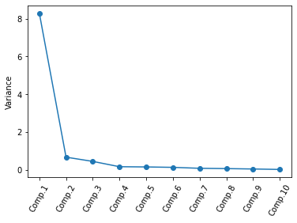

```python
y = np.std(pca.transform(X), axis=0)**2
x = np.arange(len(y)) + 1
plt.plot(x, y, "o-")
plt.xticks(x, ["Comp."+str(i) for i in x], rotation=60)
plt.ylabel("Variance")
plt.show()
```

#### Observation :

First Principal Component is sufficient in explaining the maximum variation.

### Summarizing Performance By Region

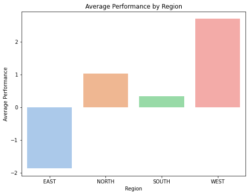

```python
# Group the data by region and calculate the average performance for each region
average_performance_by_region = data.groupby('Region')['performance'].mean().reset_index()
colors = sns.color_palette("pastel")

# Create a bar graph using the specified color palette
plt.figure(figsize=(8, 6))
#Plotting bar graph
sns.barplot(data=average_performance_by_region, x='Region', y='performance', palette=colors)
plt.title('Average Performance by Region')
plt.xlabel('Region')
plt.ylabel('Average Performance')
plt.xticks(rotation=0)
plt.show()
```

#### Observation :

The data suggests significant regional variations in performance indicator. "WEST" stands out with the highest positive value, indicating superior performance, while "EAST" has the lowest negative value, implying below-average performance.